# StoutQ2

Name: Adeep Avinash Kulkarni Question: Stout Case Study Q2 Position: Data and Digital Analytics Intern

Let’s import the dataset into a local dataframe to begin with

```r
library(tidyverse)
orders_data <- read_csv('/Users/adeepkulkarni/Downloads/casestudy.csv')
```

```
## * `` -> ...1
```

Let’s learn a bit about the dataframe first, its structure, statistics and first 6 elements

```r
str(orders_data)
```

```
## spec_tbl_df [685,927 × 4] (S3: spec_tbl_df/tbl_df/tbl/data.frame)
##  $ ...1          : num [1:685927] 0 1 2 3 4 5 6 7 8 9 ...
##  $ customer_email: chr [1:685927] "nhknapwsbx@gmail.com" "joiuzbvcpn@gmail.com" "ukkjctepxt@gmail.com" "gykatilzrt@gmail.com" ...
##  $ net_revenue   : num [1:685927] 249.9 87.6 168.4 62.4 43.1 ...
##  $ year          : num [1:685927] 2015 2015 2015 2015 2015 ...
##  - attr(*, "spec")=
##   .. cols(
##   ..   ...1 = col_double(),
##   ..   customer_email = col_character(),
##   ..   net_revenue = col_double(),
##   ..   year = col_double()
##   .. )
##  - attr(*, "problems")=<externalptr>
```

```r
summary(orders_data)
```

```
##       ...1        customer_email      net_revenue          year
##  Min.   :     0   Length:685927      Min.   :  1.00   Min.   :2015
##  1st Qu.:171482   Class :character   1st Qu.: 63.51   1st Qu.:2015
##  Median :342963   Mode  :character   Median :125.73   Median :2016
##  Mean   :342963                      Mean   :125.65   Mean   :2016
##  3rd Qu.:514444                      3rd Qu.:187.82   3rd Qu.:2017
##  Max.   :685926                      Max.   :250.00   Max.   :2017
```

```r
head(orders_data)
```

```
## # A tibble: 6 × 4
##    ...1 customer_email       net_revenue  year
##   <dbl> <chr>                      <dbl> <dbl>
## 1     0 nhknapwsbx@gmail.com       250.   2015
## 2     1 joiuzbvcpn@gmail.com        87.6  2015
## 3     2 ukkjctepxt@gmail.com       168.   2015
## 4     3 gykatilzrt@gmail.com        62.4  2015
## 5     4 mmsgsrtxah@gmail.com        43.1  2015
## 6     5 mobvusnzfr@gmail.com        39.4  2015
```

Let’s create a output set, starting with the variable year

```r
year <- orders_data %>% select(year) %>% unique()
output_set <- tibble(year)
output_set$year <- as.integer(output_set$year)
```

Next, cleaning the net revenue column

```r
final_revenue <- orders_data %>% group_by(year) %>% mutate(final_revenue= sum(net_revenue)) %>% select(final_revenue,year) %>% unique()
```

Adding the final revenue column to the output set

```r
output_set <- output_set %>% left_join(final_revenue,by="year")
```

Add new column called new_cust to orders_data data frame

```r
orders_data <- orders_data %>% group_by(customer_email) %>% mutate(new_cust = case_when(year == min(year) ~ TRUE, year > min(year) ~ FALSE))
```

Now, we will calculate the new customer revenue

```r
newcust_rev <- orders_data %>% filter(new_cust == TRUE) %>% group_by(year) %>% mutate(newcust_rev = sum(final_revenue)) %>% select(newcust_rev, year) %>% unique()
```

Add above value to the output set

```r
output_set <- output_set %>% left_join(newcust_rev,by="year")
```

Now we will calculate customer growth and add it to the output set

```r
output_set <- output_set %>% arrange(year) %>% mutate(cust_growth = (final_revenue - newcust_rev) - (lag(final_revenue) - lag(newcust_rev)))
```

Calculate the amount of revenue lost due to attrition and add it to the output set

```r
output_set <- output_set %>% arrange(year) %>% mutate(rev_lost = lag(final_revenue) - (final_revenue - newcust_rev))
```

Calculate current revenue growth and add to output set

```r
output_set <- output_set %>% mutate(cust_rev = final_revenue - newcust_rev)
```

Calculate previous revenue and add to output set

```r
output_set <- output_set %>% arrange(year) %>% mutate(prevcust_rev = lag(final_revenue) - lag(newcust_rev))
```

Calculate total customers and previous total customers

```r
total_cust <- orders_data %>% group_by(year) %>% mutate(total_cust = n()) %>% select(total_cust, year) %>% unique() %>%
ungroup() %>% arrange(year) %>% mutate(prev_total_cust = lag(total_cust))
```

Add these two into the output set

```r
output_set <- output_set %>% left_join(total_cust, by = "year")
```

Calculate the new customers now and add them to output set

```r
new_cust <- orders_data %>% filter(new_cust == TRUE) %>% group_by(year) %>% mutate(new_cust = n()) %>% select(new_cust, year) %>% unique()

output_set <- output_set %>%left_join(new_cust, by = "year")
```

Calculate the lost customers and add them to the output set

```r
output_set <- output_set %>% arrange(year) %>% mutate(lost_cust = lag(total_cust) - (total_cust - new_cust))
```

```r
str(output_set)
```

```
## tibble [3 × 11] (S3: tbl_df/tbl/data.frame)
##  $ year           : num [1:3] 2015 2016 2017
##  $ final_revenue  : num [1:3] 29036749 25730944 31417495
##  $ newcust_rev    : num [1:3] 86191236 86191236 86191236
##  $ cust_growth    : num [1:3] NA -3305806 5686551
##  $ rev_lost       : num [1:3] NA 89497041 80504684
##  $ cust_rev       : num [1:3] -57154487 -60460292 -54773741
##  $ prevcust_rev   : num [1:3] NA -57154487 -60460292
##  $ total_cust     : int [1:3] 231294 204646 249987
##  $ prev_total_cust: int [1:3] NA 231294 204646
##  $ new_cust       : int [1:3] 231294 136891 173449
##  $ lost_cust      : int [1:3] NA 163539 128108
```

Let’s check the elements of this

```r
output_set
```

```
## # A tibble: 3 × 11
##    year final_revenue newcust_rev cust_growth  rev_lost   cust_rev prevcust_rev
##   <dbl>         <dbl>       <dbl>       <dbl>     <dbl>      <dbl>        <dbl>
## 1  2015     29036749.   86191236.         NA        NA  -57154487.          NA
## 2  2016     25730944.   86191236.   -3305806. 89497041. -60460292.   -57154487.
## 3  2017     31417495.   86191236.    5686551. 80504684. -54773741.   -60460292.
## # … with 4 more variables: total_cust <int>, prev_total_cust <int>,
## #   new_cust <int>, lost_cust <int>
```

Now we will make some visualizations of this output set

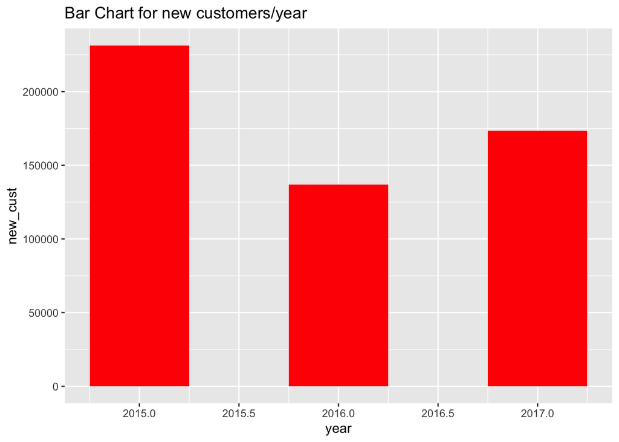

```r
bar_chart <- ggplot(output_set, aes(year, new_cust))
bar_chart + geom_bar(stat="identity", width = 0.5, fill="red") +
      labs(title="Bar Chart for new customers/year", xlab="year", ylab="new customers")
```

Density plot next

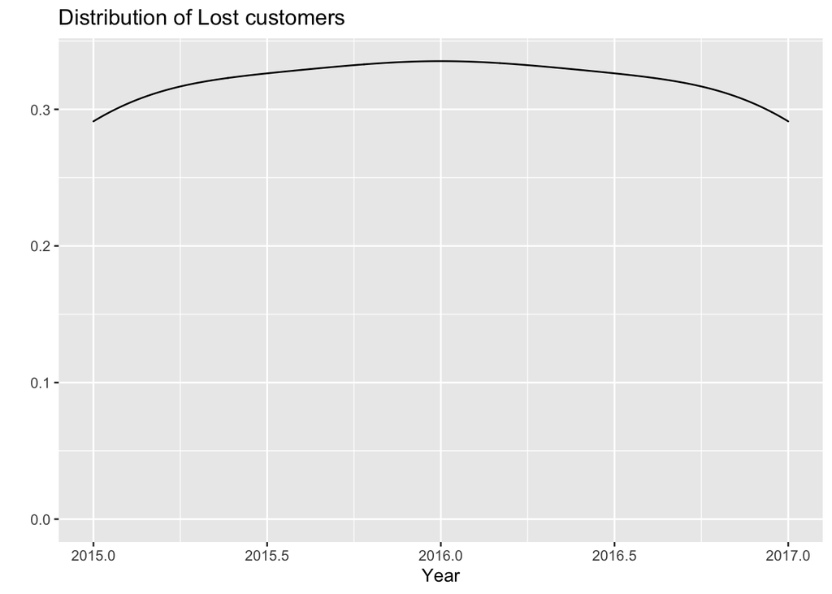

```r
output_set %>%
  ggplot(aes(x = year, color = lost_cust)) +
  geom_density() +
  labs(x = "Year", y = "", title = "Distribution of Lost customers")
```

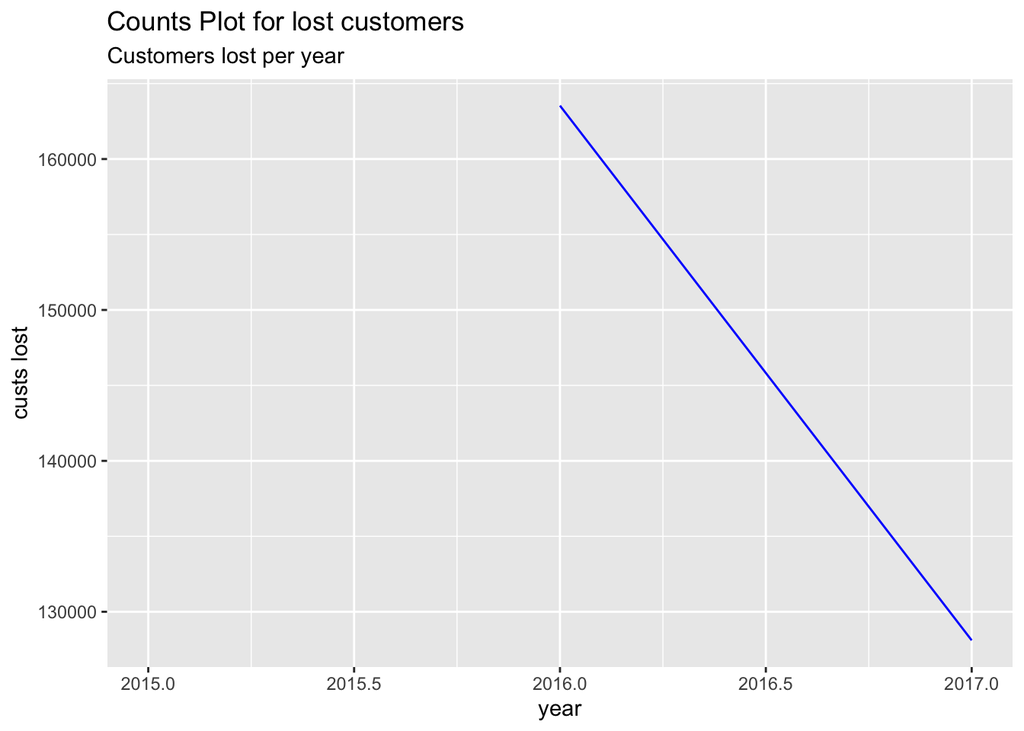

```r
boxplot <- ggplot(output_set, aes(year,lost_cust))
boxplot + geom_line(col="blue",show.legend=F) +
  labs(subtitle="Customers lost per year ",
       y="custs lost",
       x="year",
       title="Counts Plot for lost customers")
```

Finally, lets check a % of new customers

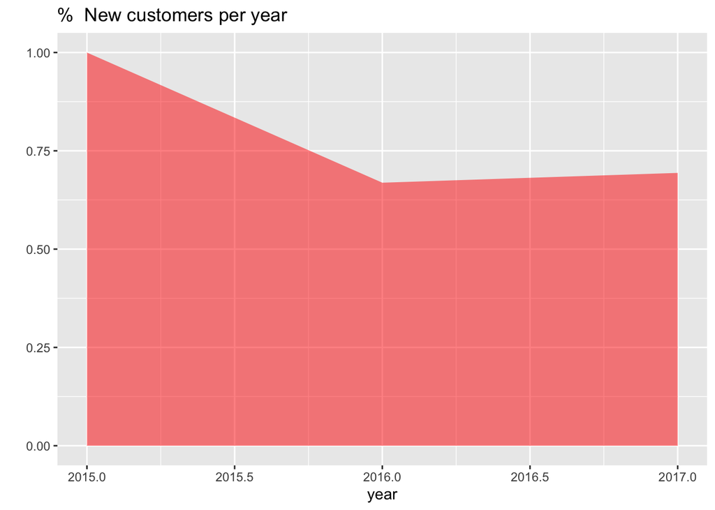

```r
output_set %>%
  ggplot() +
  geom_area(aes(x = year, y = new_cust / total_cust), fill = "red", alpha = .5) +
  labs(x = "year", y = "", title = "%  New customers per year")
```